# 1. Defining the question

# 5. Exploratory Data Analysis

## a) Univariate Analysis of Categorical Variables

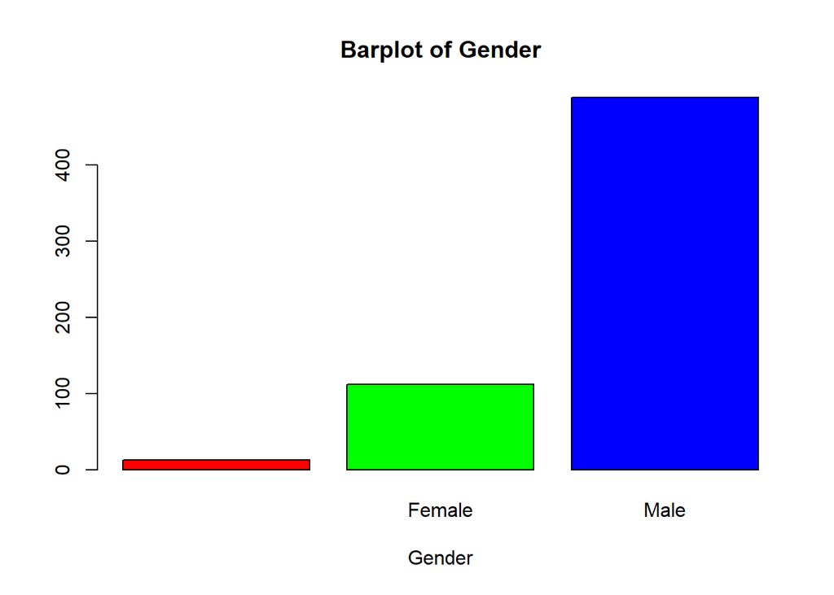

```r
#barplots of categorical variables

barplot(table(train$Gender), main="Barplot of Gender",xlab="Gender", col= rainbow(3))
```

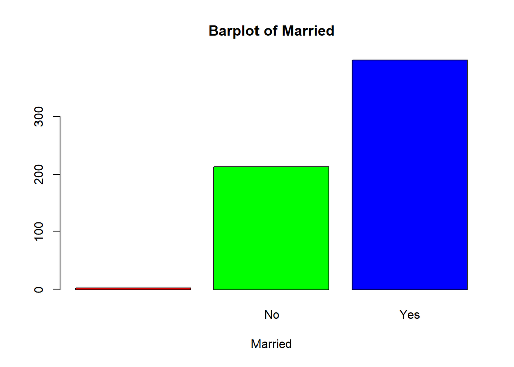

```r
barplot(table(train$Married), main="Barplot of Married",xlab="Married", col= rainbow(3))
```

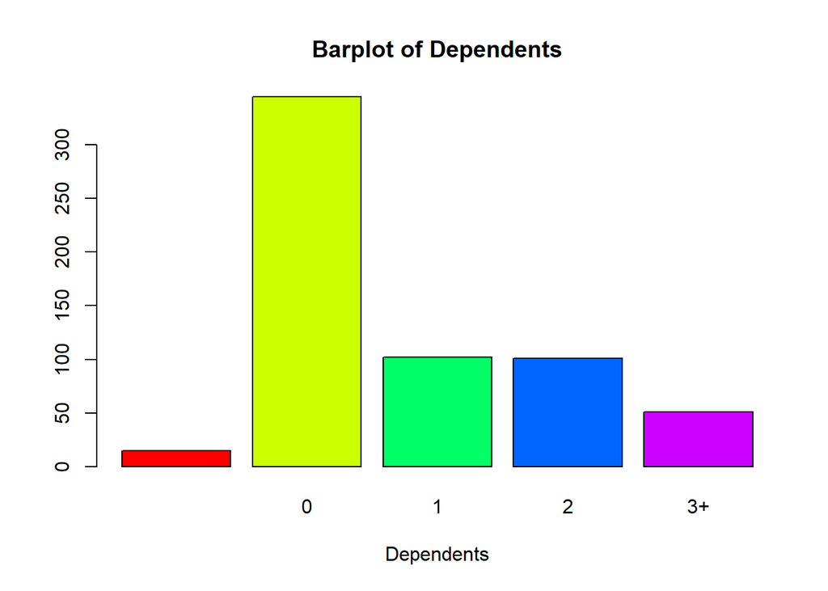

```r
barplot(table(train$Dependents), main="Barplot of Dependents",xlab="Dependents", col= rainbow(5))
```

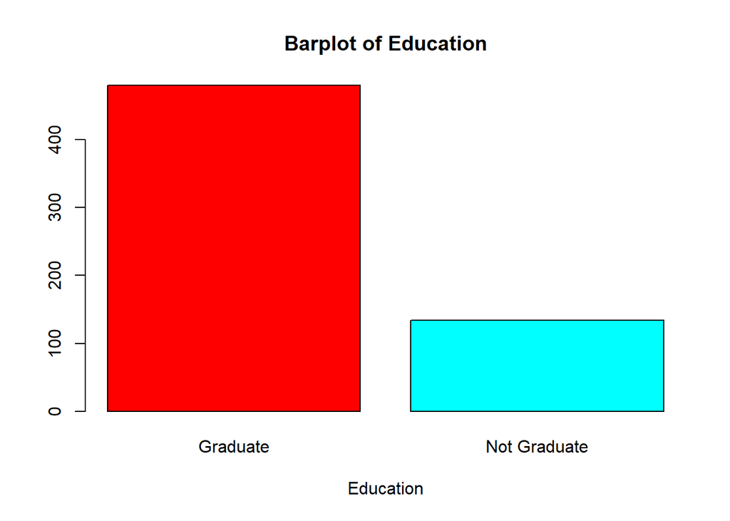

```r
barplot(table(train$Education), main="Barplot of Education",xlab="Education", col= rainbow(2))
```

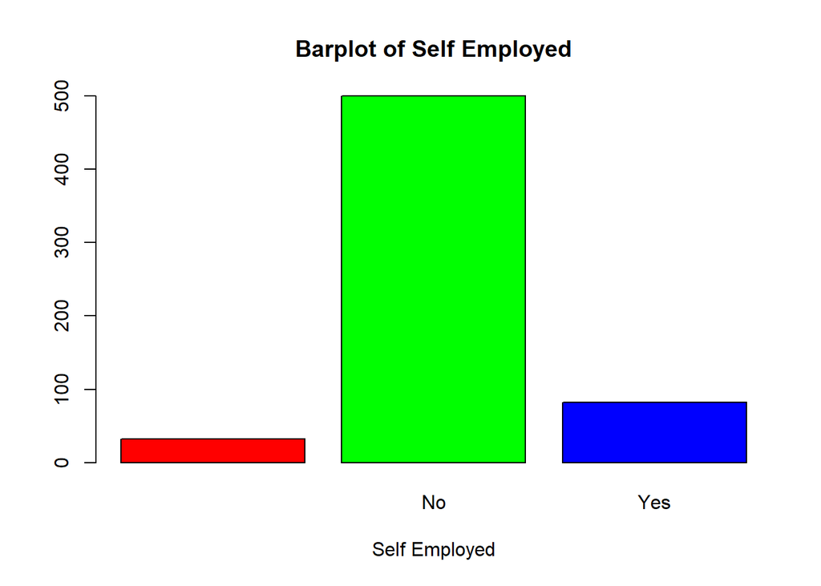

```r
barplot(table(train$Self_Employed), main="Barplot of Self Employed",xlab="Self Employed", col= rainbow(3))
```

[figure not shown]

```r
barplot(table(train$Gender), main="Barplot of Property Area",xlab="Property Area", col= rainbow(3))
```

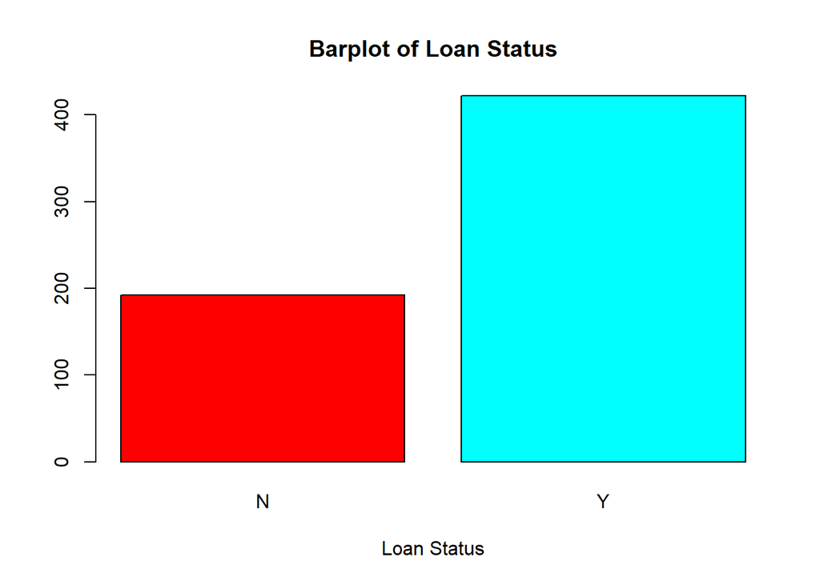

```r
barplot(table(train$Loan_Status), main="Barplot of Loan Status",xlab="Loan Status", col= rainbow(2))
```

Majority of the individuals represented in the dataset: a) Male gender b) Married c) Have 0 dependents d) Are graduates e) are not self-employed f) have a loan status of ‘Y’

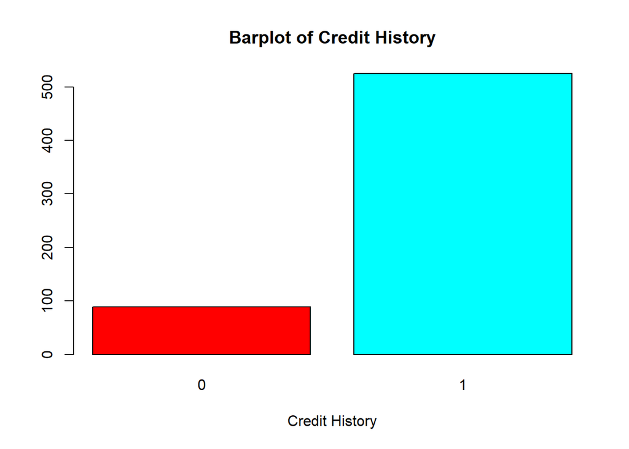

```r
#correctly visualizing CreditHistory
barplot(table(train$Credit_History), main="Barplot of Credit History",xlab="Credit History", col= rainbow(2))
```

Most of the people in the dataset have a credit history

## b) Bivariate Analysis

To simplify this step variables will be plotted against our target variable, LoanStatus

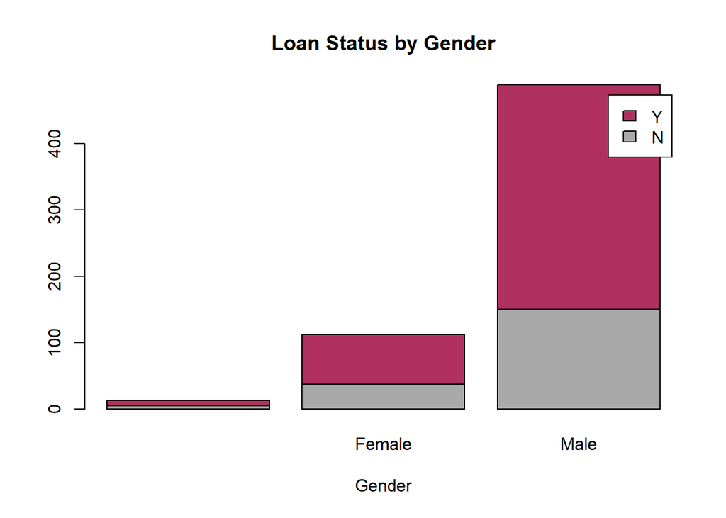

```r
counts <- table(train$Loan_Status, train$Gender)
barplot(counts, main="Loan Status by Gender",
        xlab="Gender", col=c("darkgrey","maroon"),
        legend = rownames(counts))
```

Majority of borrowers are male

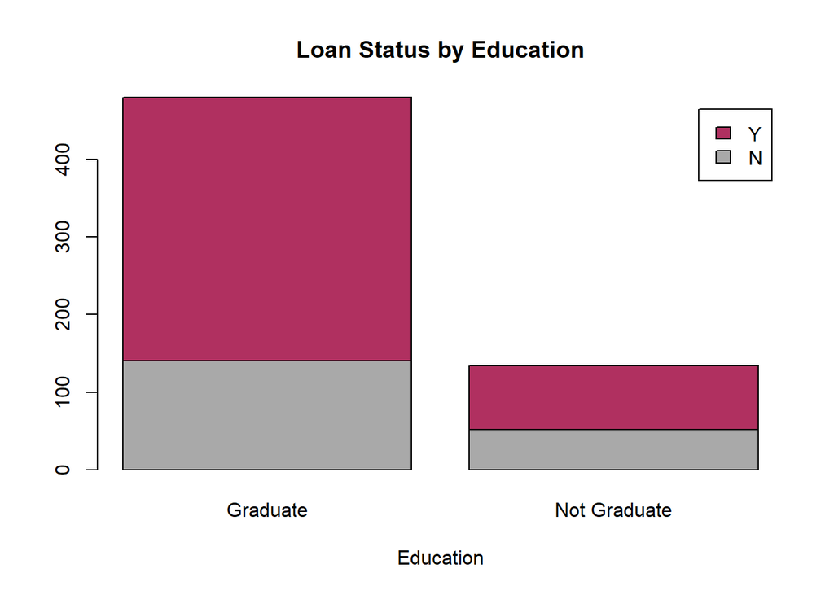

```r
counts2 <- table(train$Loan_Status, train$Education)
barplot(counts2, main="Loan Status by Education",
        xlab="Education", col=c("darkgrey","maroon"),
        legend = rownames(counts2))
```

Majority of borrowers are graduates

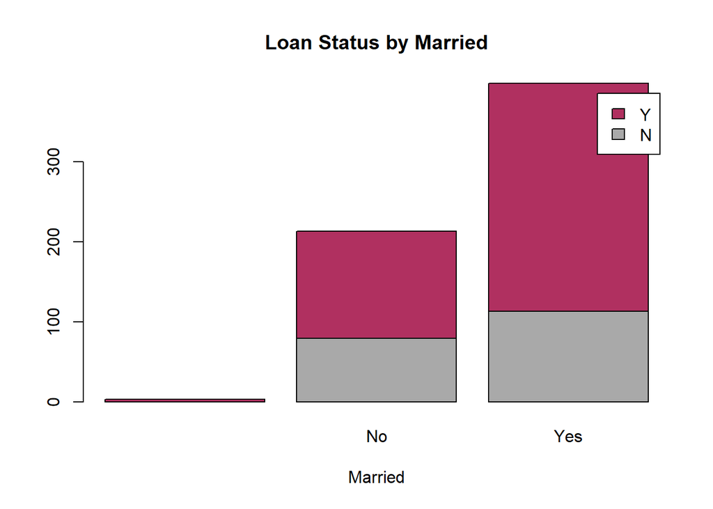

```r
counts3 <- table(train$Loan_Status, train$Married)
barplot(counts3, main="Loan Status by Married",
        xlab="Married", col=c("darkgrey","maroon"),
        legend = rownames(counts3))
```

Most borrowers are married

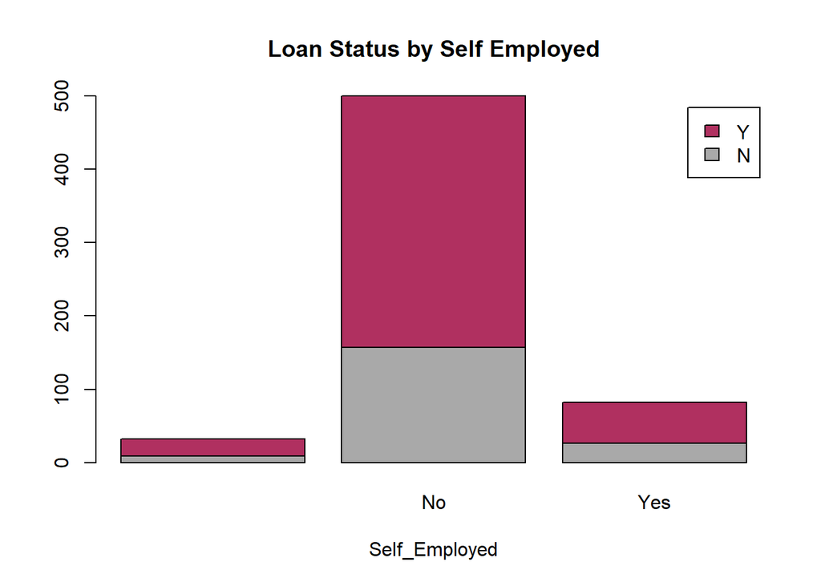

```r
counts4 <- table(train$Loan_Status, train$Self_Employed)
barplot(counts4, main="Loan Status by Self Employed",
        xlab="Self_Employed", col=c("darkgrey","maroon"),
        legend = rownames(counts4))
```

Most of the borrowers are not self-employed

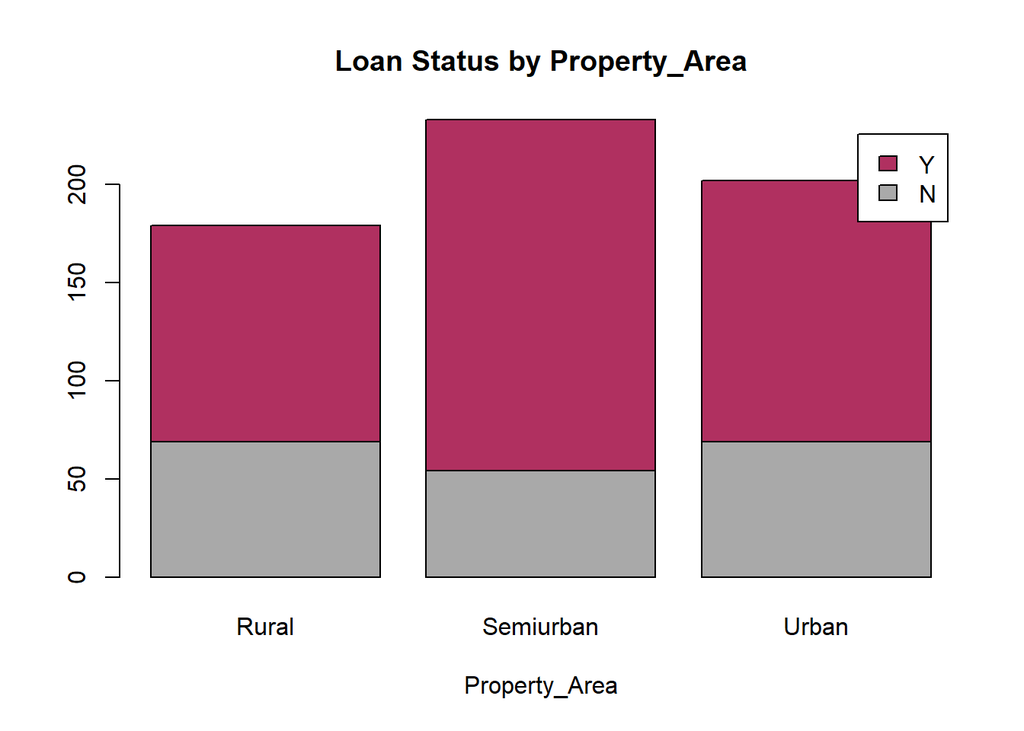

```r
counts5 <- table(train$Loan_Status, train$Property_Area)
barplot(counts5, main="Loan Status by Property_Area",
        xlab="Property_Area", col=c("darkgrey","maroon"),
        legend = rownames(counts5))
```

$the property locations are almost equally distributed among rural, urban and semi-urban areas. However, the majority of the homes are in Semiurban areas

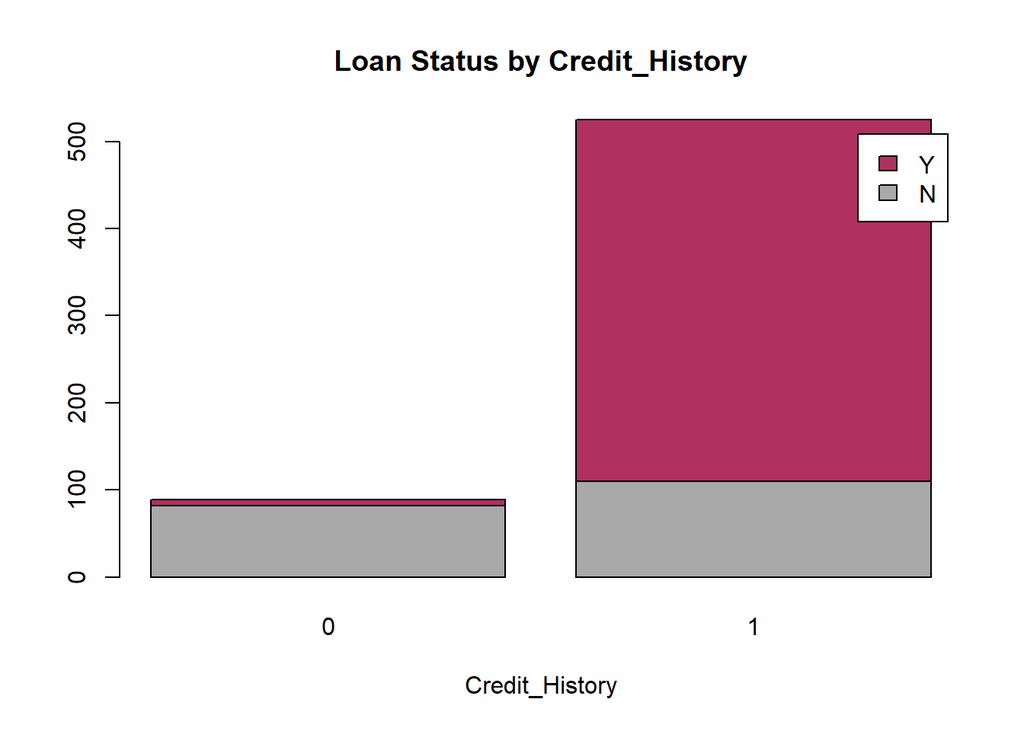

```r
counts6 <- table(train$Loan_Status, train$Credit_History)
barplot(counts6, main="Loan Status by Credit_History",
        xlab="Credit_History", col=c("darkgrey","maroon"),
        legend = rownames(counts5))
```

From the proportions, having a credit history makes it far more likely for you to have a loan Status of ‘Y’.

# 6.Data Pre-processing

```r
#checking the proportion of the target variable
prop.table(table(train$Loan_Status))%>% round(2)
```

```
##
##    N    Y
## 0.31 0.69
```

```r
#The data has a ratio of close to 1:2
```

## Feature Engineering and Log transformation

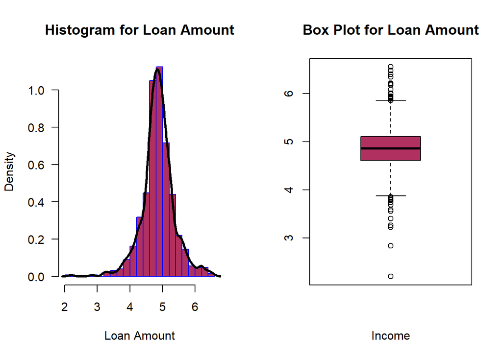

```r
#from the histograms in the outlier/univariate analysis section, the data has extreme outliers which I chose to keep. The data is also skewed.
#We are going to carry out a log transform to normalize the data, thus reducing bias

train$LogLoanAmount <- log(train$LoanAmount)
par(mfrow=c(1,2))
hist(train$LogLoanAmount,
     main="Histogram for Loan Amount",
     xlab="Loan Amount",
     border="blue",
     col="maroon",
     las=1,
     breaks=20, prob = TRUE)
lines(density(train$LogLoanAmount), col='black', lwd=3)
boxplot(train$LogLoanAmount, col='maroon',xlab = 'Income', main = 'Box Plot for Loan Amount')
```

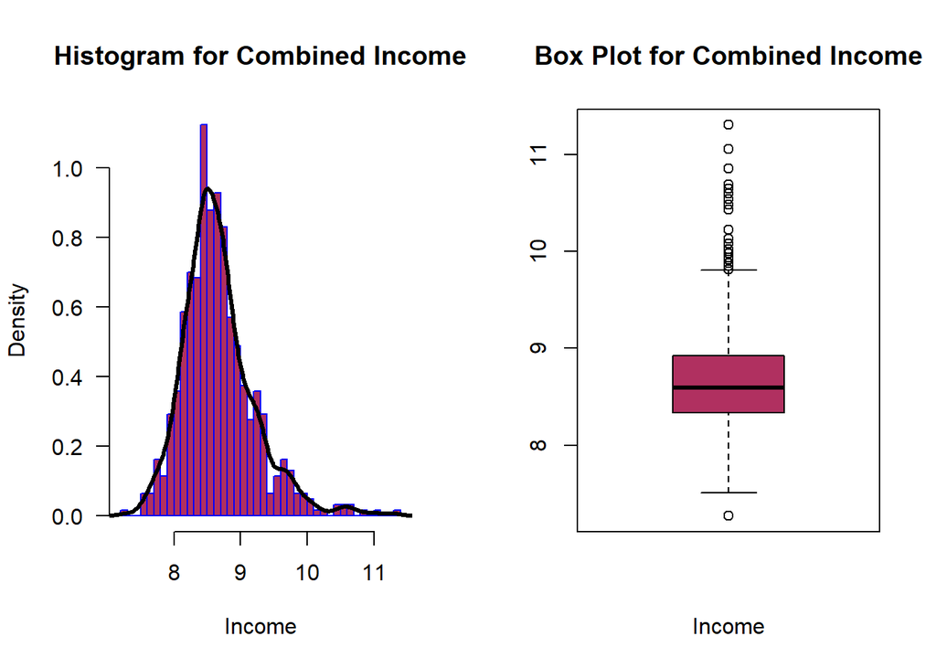

```r
#combining the applicant income and coapplicant income, this seems to be the most conventional way of working with this dataset
#Note: The applicantincome and coapplicantIncome both have extreme outliers so they are subject to log transformation
train$Income <- train$ApplicantIncome + train$CoapplicantIncome
train$ApplicantIncome <- NULL
train$CoapplicantIncome <- NULL
train$LogIncome <- log(train$Income)
par(mfrow=c(1,2))
hist(train$LogIncome,
     main="Histogram for Combined Income",
     xlab="Income",
     border="blue",
     col="maroon",
     las=1,
     breaks=50, prob = TRUE)
lines(density(train$LogIncome), col='black', lwd=3)
boxplot(train$LogIncome, col='maroon',xlab = 'Income', main = 'Box Plot for Combined Income')
```

```r
#the data is somewhat normal, hence will give better results than it would in its initial form
```

```r
#reviewing data to see changes
head(train)
```

```
##    Loan_ID Gender Married Dependents    Education Self_Employed LoanAmount
## 1 LP001002   Male      No          0     Graduate            No   146.4122
## 2 LP001003   Male     Yes          1     Graduate            No   128.0000
## 3 LP001005   Male     Yes          0     Graduate           Yes    66.0000
## 4 LP001006   Male     Yes          0 Not Graduate            No   120.0000
## 5 LP001008   Male      No          0     Graduate            No   141.0000
## 6 LP001011   Male     Yes          2     Graduate           Yes   267.0000
##   Loan_Amount_Term Credit_History Property_Area Loan_Status LogLoanAmount
## 1              360              1         Urban           Y      4.986426
## 2              360              1         Rural           N      4.852030
## 3              360              1         Urban           Y      4.189655
## 4              360              1         Urban           Y      4.787492
## 5              360              1         Urban           Y      4.948760
## 6              360              1         Urban           Y      5.587249
##   Income LogIncome
## 1   5849  8.674026
## 2   6091  8.714568
## 3   3000  8.006368
## 4   4941  8.505323
## 5   6000  8.699515
## 6   9613  9.170872
```

```r
#removing loanAmount and The combined Applicants' income i.e. Income variable

train$Income <- NULL
train$LoanAmount <- NULL
```

```r
#splitting into train and test set at 70%:30%
#due to the size of the data having a slightly smaller train set than usual, the 70:30 split is good to help avoid over-fitting

#set.seed(123)
#sample <- sample.int(n = nrow(train), size = floor(.70*nrow(train)), replace = FALSE)
#trainn <- train[sample, ]
#testn  <- train[-sample, ]
```